# Datafiniti Hotel-Reviews

**Description**  
This dataset is a list of about 2,000 hotels and 10,000 reviews from Datafiniti's Business Database updated between January 2018 to September 2018.

**Source**  
https://data.world/datafiniti/hotel-reviews

**Business data schema**  
https://developer.datafiniti.co/docs/business-data-schema

1. Import and examine the dataset
2. Create fact and dim tables
3. Write data pipeline script
4. Load and visualize data

```python
import pandas as pd
import numpy as np
import datetime
import sqlite3
from sqlalchemy import create_engine
import hashlib
import seaborn as sns

import matplotlib.pyplot as plt
%matplotlib inline
```

### 1. Import and examine the dataset

```python
%%time
url = 'https://query.data.world/s/ocnrbnvwejhrerodkfh75grm6tp34h'
df = pd.read_csv(url)
```

```
Wall time: 21.8 s
```

```python
df.head(5)
```

|  | id | dateAdded | dateUpdated | address | categories | primaryCategories | city | country | keys | latitude | ... | reviews.dateSeen | reviews.rating | reviews.sourceURLs | reviews.text | reviews.title | reviews.userCity | reviews.userProvince | reviews.username | sourceURLs | websites |
| --- | --- | --- | --- | --- | --- | --- | --- | --- | --- | --- | --- | --- | --- | --- | --- | --- | --- | --- | --- | --- | --- |
| 0 | AVwc252WIN2L1WUfpqLP | 2016-10-30T21:42:42Z | 2018-09-10T21:06:27Z | 5921 Valencia Cir | Hotels,Hotels and motels,Hotel and motel reser... | Accommodation & Food Services | Rancho Santa Fe | US | us/ca/ranchosantafe/5921valenciacir/359754519 | 32.990959 | ... | 2016-08-03T00:00:00Z,2016-07-26T00:00:00Z,2016... | 5.0 | https://www.hotels.com/hotel/125419/reviews%20/ | Our experience at Rancho Valencia was absolute... | Best romantic vacation ever!!!! | NaN | NaN | Paula | http://www.hotels.com/ho125419/%25252525253Flo... | http://www.ranchovalencia.com |
| 1 | AVwc252WIN2L1WUfpqLP | 2016-10-30T21:42:42Z | 2018-09-10T21:06:27Z | 5921 Valencia Cir | Hotels,Hotels and motels,Hotel and motel reser... | Accommodation & Food Services | Rancho Santa Fe | US | us/ca/ranchosantafe/5921valenciacir/359754519 | 32.990959 | ... | 2016-08-02T00:00:00Z,2016-08-26T00:00:00Z,2016... | 5.0 | https://www.hotels.com/hotel/125419/reviews%20/ | Amazing place. Everyone was extremely warm and... | Sweet sweet serenity | NaN | NaN | D | http://www.hotels.com/ho125419/%25252525253Flo... | http://www.ranchovalencia.com |
| 2 | AVwc252WIN2L1WUfpqLP | 2016-10-30T21:42:42Z | 2018-09-10T21:06:27Z | 5921 Valencia Cir | Hotels,Hotels and motels,Hotel and motel reser... | Accommodation & Food Services | Rancho Santa Fe | US | us/ca/ranchosantafe/5921valenciacir/359754519 | 32.990959 | ... | 2016-11-15T00:00:00Z,2016-08-23T00:00:00Z,2016... | 5.0 | https://www.hotels.com/hotel/125419/reviews%20/ | We booked a 3 night stay at Rancho Valencia to... | Amazing Property and Experience | NaN | NaN | Ron | http://www.hotels.com/ho125419/%25252525253Flo... | http://www.ranchovalencia.com |
| 3 | AVwdOclqIN2L1WUfti38 | 2015-11-28T19:19:35Z | 2018-09-10T21:06:16Z | 7520 Teague Rd | Hotels,Hotels and motels,Travel agencies and b... | Accommodation & Food Services | Hanover | US | us/md/hanover/7520teaguerd/-2043779672 | 39.155929 | ... | 2016-05-21T00:00:00Z,2016-07-31T00:00:00Z | 2.0 | https://www.tripadvisor.com/Hotel_Review-g4118... | Currently in bed writing this for the past hr ... | Never again...beware, if you want sleep. | Richmond | VA | jaeem2016 | http://www.yellowbook.com/profile/aloft-arunde... | http://www.starwoodhotels.com/alofthotels/prop... |
| 4 | AVwdOclqIN2L1WUfti38 | 2015-11-28T19:19:35Z | 2018-09-10T21:06:16Z | 7520 Teague Rd | Hotels,Hotels and motels,Travel agencies and b... | Accommodation & Food Services | Hanover | US | us/md/hanover/7520teaguerd/-2043779672 | 39.155929 | ... | 2016-07-31T00:00:00Z | 5.0 | https://www.tripadvisor.com/Hotel_Review-g4118... | I live in Md and the Aloft is my Home away fro... | ALWAYS GREAT STAY... | Laurel | MD | MamaNiaOne | http://www.yellowbook.com/profile/aloft-arunde... | http://www.starwoodhotels.com/alofthotels/prop... |

5 rows × 25 columns

```python
print('The dataset has a shape of {}.\n'.format(df.shape))
print("Let's take a look at the datatypes\n{}".format(df.dtypes))
```

```
The dataset has a shape of (10000, 25).

Let's take a look at the datatypes
id                       object
dateAdded                object
dateUpdated              object
address                  object
categories               object
primaryCategories        object
city                     object
country                  object
keys                     object
latitude                float64
longitude               float64
name                     object
postalCode               object
province                 object
reviews.date             object
reviews.dateSeen         object
reviews.rating          float64
reviews.sourceURLs       object
reviews.text             object
reviews.title            object
reviews.userCity         object
reviews.userProvince     object
reviews.username         object
sourceURLs               object
websites                 object
dtype: object
```

```python
df.describe()
```

|  | latitude | longitude | reviews.rating |
| --- | --- | --- | --- |
| count | 10000.000000 | 10000.000000 | 10000.000000 |
| mean | 37.003630 | -92.675934 | 4.034265 |
| std | 5.517273 | 19.347989 | 1.162240 |
| min | 19.438604 | -159.474930 | 1.000000 |
| 25% | 33.927588 | -111.622343 | 3.350000 |
| 50% | 37.785060 | -84.452114 | 4.000000 |
| 75% | 40.416380 | -77.052700 | 5.000000 |
| max | 70.133620 | -68.203990 | 5.000000 |

```python
df.info()
```

```
<class 'pandas.core.frame.DataFrame'>
RangeIndex: 10000 entries, 0 to 9999
Data columns (total 25 columns):
id                      10000 non-null object
dateAdded               10000 non-null object
dateUpdated             10000 non-null object
address                 10000 non-null object
categories              10000 non-null object
primaryCategories       10000 non-null object
city                    10000 non-null object
country                 10000 non-null object
keys                    10000 non-null object
latitude                10000 non-null float64
longitude               10000 non-null float64
name                    10000 non-null object
postalCode              10000 non-null object
province                10000 non-null object
reviews.date            10000 non-null object
reviews.dateSeen        10000 non-null object
reviews.rating          10000 non-null float64
reviews.sourceURLs      10000 non-null object
reviews.text            9999 non-null object
reviews.title           9999 non-null object
reviews.userCity        4164 non-null object
reviews.userProvince    2705 non-null object
reviews.username        10000 non-null object
sourceURLs              10000 non-null object
websites                10000 non-null object
dtypes: float64(3), object(22)
memory usage: 1.9+ MB
```

```python
df.columns
```

```
Index(['id', 'dateAdded', 'dateUpdated', 'address', 'categories',
       'primaryCategories', 'city', 'country', 'keys', 'latitude', 'longitude',
       'name', 'postalCode', 'province', 'reviews.date', 'reviews.dateSeen',
       'reviews.rating', 'reviews.sourceURLs', 'reviews.text', 'reviews.title',
       'reviews.userCity', 'reviews.userProvince', 'reviews.username',
       'sourceURLs', 'websites'],
      dtype='object')
```

```python
#https://www.pythoncentral.io/hashing-strings-with-python/
hash_object = hashlib.sha224(b'Hello World')
print(hash_object)
hash_object.hexdigest()
```

```
<sha224 HASH object @ 0x00000215BBFB2A80>
```

```
'c4890faffdb0105d991a461e668e276685401b02eab1ef4372795047'
```

```python
url_states = 'https://www.downloadexcelfiles.com/sites/default/files/docs/list-states-us-36j.csv'
df_states = pd.read_csv(url_states,  header=1, skiprows=[2])
df_states.dropna(axis=0, inplace=True)
df_states.head()
```

|  | Sr.No | State | Abbr. | Capital | Largest city | Statehood | Population est. | Total area in mi2 (km2) | Land area in mi2 (km2) | Water area in mi2 (km2) |
| --- | --- | --- | --- | --- | --- | --- | --- | --- | --- | --- |
| 0 | 1 | Alabama | AL | Montgomery | Birmingham | December 14, 1819 | 48,22,023 | 52,420 (135,767) | 50,645 (131,170) | 1,775 (4,597) |
| 1 | 2 | Alaska | AK | Juneau | Anchorage | January 3, 1959 | 7,31,449 | 665,384 (1,723,337) | 570,641 (1,477,950) | 94,743 (245,383) |
| 2 | 3 | Arizona | AZ | Phoenix | Phoenix | February 14, 1912 | 65,53,255 | 113,990 (295,233) | 113,594 (294,207) | 396 (1,026) |
| 3 | 4 | Arkansas | AR | Little Rock | Little Rock | June 15, 1836 | 29,49,131 | 53,179 (137,733) | 52,035 (134,770) | 1,143 (2,960) |
| 4 | 5 | California | CA | Sacramento | Los Angeles | September 9, 1850 | 3,80,41,430 | 163,695 (423,968) | 155,779 (403,466) | 7,916 (20,502) |

### 2. Create fact and dim tables

Introducing a lambda hash function, in SQL I usually use MD5 or something similar. For reasons of simplicity I skip the plumbing columns (dw_ins_upd_dts and dw_etl_run_num) as there is not really an incremental load here. However, this could be introduced with a later version.

I'm creating fact tables for the granular ratings:

- fact_rating

as well as dim tables for users, states and hotels:

- dim_user
- dim_hotel
- dim_state
- dim_cal (just a basic one, the logic behind can be extended)

as well as aggregated fact tables for users, states and hotels:

- fact_user
- fact_state
- fact_hotel
- fact_rating_2 (that's the raw fact enlarged with all dims for python plotting, not really best practice, but convenient for plotting)

I did the aggregated fact tables for users, states and hotels just for demonstration purposes. Actually the same result could be achieved in reporting layer with fact_rating_2 table. It depends on the size of the dataset and to what degree the reports should be aggregated before the reporting. With this dataset we can do the visualization part also on fact_rating_2 table (which is unaggregated). It is always a matter of requirements.

I skip stages of the datawarehouse modeling chain due to lack of time and the lack of incremental data loads.

A chain could look like: **`STAGE_INC`** -> **`STAGE`** -> **`BASE`** -> **`PACKAGE`** / **`REPORTING`**

Usually the aggregations are done in **`PACKAGE`** / **`REPORTING`** stage..

```python
hash_function = lambda x: hashlib.sha256(str(str(x)).encode('utf-8')).hexdigest()
```

**fact table rating**

```python
columns_fact_ratings = ['id', 'reviews.date', 'reviews.dateSeen', 'reviews.rating', 'reviews.sourceURLs',
                'reviews.text', 'reviews.title', 'reviews.username', 'sourceURLs', 'province']
helper = df[columns_fact_ratings]
print(columns_fact_ratings)
```

```
['id', 'reviews.date', 'reviews.dateSeen', 'reviews.rating', 'reviews.sourceURLs', 'reviews.text', 'reviews.title', 'reviews.username', 'sourceURLs', 'province']
```

```python
convert_datetime_to_date = lambda x: datetime.datetime.strptime(x[:10], '%Y-%m-%d').date()
return_uppercase = lambda x: x.upper()
```

```python
columns_fact_ratings_2=['DW_ID_HASH_KEY', 'DW_ID_HASH_KEY_HOTEL','REVIEWS_DATE', 'REVIEWS_DATESEEN', 'REVIEWS_RATING',
                        'REVIEWS_SOURCEURLS', 'REVIEWS_TEXT', 'REVIEWS_TITLE', 'DW_ID_HASH_KEY_USER', 'DW_ID_HASH_KEY_STATE']

df_fact_rating = pd.DataFrame(columns=columns_fact_ratings_2)

df_fact_rating['DW_ID_HASH_KEY'] =          (helper['id']+'_'+helper['reviews.username']+'_'+helper['reviews.date'])\
                                            .apply(hash_function)
df_fact_rating['DW_ID_HASH_KEY_HOTEL'] =    helper['id'].apply(hash_function)
df_fact_rating['DW_ID_HASH_KEY_USER'] =     helper['reviews.username'].apply(hash_function)
df_fact_rating['DW_ID_HASH_KEY_STATE'] =    (helper['province'].apply(return_uppercase)).apply(hash_function)

df_fact_rating['REVIEWS_DATE'] =        helper['reviews.date'].apply(convert_datetime_to_date).astype('datetime64[ns]')
df_fact_rating['REVIEWS_DATESEEN'] =    helper['reviews.dateSeen']
df_fact_rating['REVIEWS_RATING'] =      helper['reviews.rating'].astype(float)
df_fact_rating['REVIEWS_SOURCEURLS'] =  helper['reviews.sourceURLs']
df_fact_rating['REVIEWS_TEXT'] =        helper['reviews.text']
df_fact_rating['REVIEWS_TITLE'] =       helper['reviews.title']
```

```python
df_fact_rating.head(2)
```

|  | DW_ID_HASH_KEY | DW_ID_HASH_KEY_HOTEL | REVIEWS_DATE | REVIEWS_DATESEEN | REVIEWS_RATING | REVIEWS_SOURCEURLS | REVIEWS_TEXT | REVIEWS_TITLE | DW_ID_HASH_KEY_USER | DW_ID_HASH_KEY_STATE |
| --- | --- | --- | --- | --- | --- | --- | --- | --- | --- | --- |
| 0 | 072759d9522169a187032176b968f23e02cdf17da050db... | ed561221139791591f43b1fc4eb5bca4d167489c806b87... | 2013-11-14 | 2016-08-03T00:00:00Z,2016-07-26T00:00:00Z,2016... | 5.0 | https://www.hotels.com/hotel/125419/reviews%20/ | Our experience at Rancho Valencia was absolute... | Best romantic vacation ever!!!! | d62ab489c56cc56115c1db613929315490e2a8d01e6b85... | 4b650e5c4785025dee7bd65e3c5c527356717d7a1c0bfe... |
| 1 | 1fd7812c218104abe74fc6d797f9276d0b7e30fece35c6... | ed561221139791591f43b1fc4eb5bca4d167489c806b87... | 2014-07-06 | 2016-08-02T00:00:00Z,2016-08-26T00:00:00Z,2016... | 5.0 | https://www.hotels.com/hotel/125419/reviews%20/ | Amazing place. Everyone was extremely warm and... | Sweet sweet serenity | 3f39d5c348e5b79d06e842c114e6cc571583bbf44e4b0e... | 4b650e5c4785025dee7bd65e3c5c527356717d7a1c0bfe... |

**dim table user**

```python
columns_dim_user = ['reviews.userCity', 'reviews.userProvince', 'reviews.username']
helper = df[columns_dim_user]
print(columns_dim_user)
helper.drop_duplicates(subset=['reviews.username']).shape
```

```
['reviews.userCity', 'reviews.userProvince', 'reviews.username']
```

```
(6942, 3)
```

```python
columns_dim_user_2=['DW_ID_HASH_KEY', 'USER_NAME', 'USER_CITY', 'USER_PROVINCE']

df_dim_user = pd.DataFrame(columns=columns_dim_user_2)

df_dim_user['DW_ID_HASH_KEY'] =  helper['reviews.username'].apply(hash_function)
df_dim_user['USER_NAME'] =       helper['reviews.username']
df_dim_user['USER_CITY'] =       helper['reviews.userCity']
df_dim_user['USER_PROVINCE'] =   helper['reviews.userProvince']

df_dim_user.drop_duplicates(subset=['DW_ID_HASH_KEY'],inplace=True)
```

```python
df_dim_user.head(8)
```

|  | DW_ID_HASH_KEY | USER_NAME | USER_CITY | USER_PROVINCE |
| --- | --- | --- | --- | --- |
| 0 | d62ab489c56cc56115c1db613929315490e2a8d01e6b85... | Paula | NaN | NaN |
| 1 | 3f39d5c348e5b79d06e842c114e6cc571583bbf44e4b0e... | D | NaN | NaN |
| 2 | 866b3a5cb1cb3d1e83d0ec67609ab8cc88f8d41765b3dc... | Ron | NaN | NaN |
| 3 | b99b9ad4acdecff3ecc6c615e59b22402cc8fefdece01e... | jaeem2016 | Richmond | VA |
| 4 | 5c3e57db36d392c3993c5088e0cc5a026e4b07262004a5... | MamaNiaOne | Laurel | MD |
| 5 | 1c55a5c58e87e0a774ef65c11670e938c12c11372518e9... | kevan777 | Laurel | MD |
| 6 | cea88787d5fafa85bd27a7f6754a831ff43dc5c7753f16... | Princess F | NaN | NaN |
| 7 | 2a53da33aa9c2674d8e221c57124dbedde176298efc550... | DebMurphy57 | Clayton | NC |

**dim table hotel**

```python
columns_dim_hotel = [ 'id',  'dateAdded', 'dateUpdated', 'address', 'categories', 'primaryCategories', 'city',
                     'country', 'latitude', 'longitude', 'name', 'postalCode', 'province']
helper = df[columns_dim_hotel]
print(columns_dim_hotel)
```

```
['id', 'dateAdded', 'dateUpdated', 'address', 'categories', 'primaryCategories', 'city', 'country', 'latitude', 'longitude', 'name', 'postalCode', 'province']
```

```python
columns_dim_hotel_2=['DW_ID_HASH_KEY', 'DATE_ADDED', 'DATE_UPDATED', 'ADDRESS', 'CATEGORIES', 'PRIMARY_CATEGORIES', 'CITY',
                     'COUNTRY', 'LATITUDE', 'LONGITUDE', 'NAME_HOTEL', 'POSTAL_CODE', 'DW_ID_HASH_KEY_STATE']

df_dim_hotel = pd.DataFrame(columns=columns_dim_hotel_2)

df_dim_hotel['DW_ID_HASH_KEY'] =  helper['id'].apply(hash_function)
df_dim_hotel['DW_ID_HASH_KEY_STATE'] =  (helper['province'].apply(return_uppercase)).apply(hash_function)

df_dim_hotel['DATE_ADDED'] =          helper['dateAdded'].apply(convert_datetime_to_date)
df_dim_hotel['DATE_UPDATED'] =        helper['dateUpdated'].apply(convert_datetime_to_date)
df_dim_hotel['ADDRESS'] =             helper['address']
df_dim_hotel['CATEGORIES'] =          helper['categories']
df_dim_hotel['PRIMARY_CATEGORIES'] =  helper['primaryCategories']
df_dim_hotel['CITY'] =                helper['city']
df_dim_hotel['COUNTRY'] =             helper['country']
df_dim_hotel['LATITUDE'] =            helper['latitude']
df_dim_hotel['LONGITUDE'] =           helper['longitude']
df_dim_hotel['NAME_HOTEL'] =          helper['name']
df_dim_hotel['POSTAL_CODE'] =         helper['postalCode']

df_dim_hotel.drop_duplicates(subset=['DW_ID_HASH_KEY'],inplace=True)
```

```python
df_dim_hotel.head(2)
```

|  | DW_ID_HASH_KEY | DATE_ADDED | DATE_UPDATED | ADDRESS | CATEGORIES | PRIMARY_CATEGORIES | CITY | COUNTRY | LATITUDE | LONGITUDE | NAME_HOTEL | POSTAL_CODE | DW_ID_HASH_KEY_STATE |
| --- | --- | --- | --- | --- | --- | --- | --- | --- | --- | --- | --- | --- | --- |
| 0 | ed561221139791591f43b1fc4eb5bca4d167489c806b87... | 2016-10-30 | 2018-09-10 | 5921 Valencia Cir | Hotels,Hotels and motels,Hotel and motel reser... | Accommodation & Food Services | Rancho Santa Fe | US | 32.990959 | -117.186136 | Rancho Valencia Resort Spa | 92067 | 4b650e5c4785025dee7bd65e3c5c527356717d7a1c0bfe... |
| 3 | 771cd0f8e6c732d2608c99299e64ae6c4814b93aceb1f0... | 2015-11-28 | 2018-09-10 | 7520 Teague Rd | Hotels,Hotels and motels,Travel agencies and b... | Accommodation & Food Services | Hanover | US | 39.155929 | -76.716341 | Aloft Arundel Mills | 21076 | 7abcf6dac49247ef3111e13199b86b909f5ee306b0599c... |

**dim table state**

```python
columns_dim_state = list(df_states.columns)
helper = df_states
print(columns_dim_state)
```

```
['Sr.No', 'State', 'Abbr.', 'Capital', 'Largest city', 'Statehood', 'Population est.', 'Total area in mi2 (km2)', 'Land area in mi2 (km2)', 'Water area in mi2 (km2)']
```

```python
area_in_mi2 = lambda x: int(x[:x.find(' ')].replace(',',''))
area_in_km2 = lambda x: int(x[x.find(' ')+1:].replace(')','').replace('(','').replace(',',''))
```

```python
columns_dim_state_2=['DW_ID_HASH_KEY', 'NAME_STATE', 'ABBREVIATION', 'CAPITAL', 'LARGEST_CITY', 'STATEHOOD', 'POPULATION_EST', 'TOTAL_AREA_IN_MI2',
                     'TOTAL_AREA_IN_KM2', 'LAND_AREA_IN_MI2', 'LAND_AREA_IN_KM2', 'WATER_AREA_IN_MI2', 'WATER_AREA_IN_KM2']

df_dim_state = pd.DataFrame(columns=columns_dim_state_2)

df_dim_state['DW_ID_HASH_KEY'] =      helper['Abbr.'].apply(hash_function)

df_dim_state['NAME_STATE'] =          helper['State']
df_dim_state['ABBREVIATION'] =        helper['Abbr.']
df_dim_state['CAPITAL'] =             helper['Capital']
df_dim_state['LARGEST_CITY'] =        helper['Largest city']
df_dim_state['STATEHOOD'] =           helper['Statehood']
df_dim_state['POPULATION_EST'] =      helper['Population est.']
df_dim_state['TOTAL_AREA_IN_MI2'] =   helper['Total area in mi2 (km2)'].apply(area_in_mi2)
df_dim_state['TOTAL_AREA_IN_KM2'] =   helper['Total area in mi2 (km2)'].apply(area_in_km2)
df_dim_state['LAND_AREA_IN_MI2'] =    helper['Land area in mi2 (km2)'].apply(area_in_mi2)
df_dim_state['LAND_AREA_IN_KM2'] =    helper['Land area in mi2 (km2)'].apply(area_in_km2)
df_dim_state['WATER_AREA_IN_MI2'] =   helper['Water area in mi2 (km2)'].apply(area_in_mi2)
df_dim_state['WATER_AREA_IN_KM2'] =   helper['Water area in mi2 (km2)'].apply(area_in_km2)
```

```python
test = df_dim_hotel['DW_ID_HASH_KEY_STATE'].unique()[0]
df_dim_state[df_dim_state['DW_ID_HASH_KEY']==test]
```

|  | DW_ID_HASH_KEY | NAME_STATE | ABBREVIATION | CAPITAL | LARGEST_CITY | STATEHOOD | POPULATION_EST | TOTAL_AREA_IN_MI2 | TOTAL_AREA_IN_KM2 | LAND_AREA_IN_MI2 | LAND_AREA_IN_KM2 | WATER_AREA_IN_MI2 | WATER_AREA_IN_KM2 |
| --- | --- | --- | --- | --- | --- | --- | --- | --- | --- | --- | --- | --- | --- |
| 4 | 4b650e5c4785025dee7bd65e3c5c527356717d7a1c0bfe... | California | CA | Sacramento | Los Angeles | September 9, 1850 | 3,80,41,430 | 163695 | 423968 | 155779 | 403466 | 7916 | 20502 |

```python
df_dim_state.head(2)
```

|  | DW_ID_HASH_KEY | NAME_STATE | ABBREVIATION | CAPITAL | LARGEST_CITY | STATEHOOD | POPULATION_EST | TOTAL_AREA_IN_MI2 | TOTAL_AREA_IN_KM2 | LAND_AREA_IN_MI2 | LAND_AREA_IN_KM2 | WATER_AREA_IN_MI2 | WATER_AREA_IN_KM2 |
| --- | --- | --- | --- | --- | --- | --- | --- | --- | --- | --- | --- | --- | --- |
| 0 | b7aea05ac84d296afc2f35daec1541dda23ec7466ea054... | Alabama | AL | Montgomery | Birmingham | December 14, 1819 | 48,22,023 | 52420 | 135767 | 50645 | 131170 | 1775 | 4597 |
| 1 | 3c4e58eff203b042713969d15d21e5a80fcc43b7ce3c90... | Alaska | AK | Juneau | Anchorage | January 3, 1959 | 7,31,449 | 665384 | 1723337 | 570641 | 1477950 | 94743 | 245383 |

**dim table calendar**  
https://stackoverflow.com/questions/47150709/how-to-create-a-calendar-table-date-dimension-in-pandas

```python
print(df['reviews.dateSeen'].min())
print(df['reviews.dateSeen'].max())
```

```
2014-10-06T00:00:00Z
2018-08-27T00:00:00Z
```

```python
def create_date_table(start='2010-01-01', end='2020-12-31'):
    df = pd.DataFrame({"CLDR_DATE": pd.date_range(start, end)})
    df["DAY_NAME"] = df.CLDR_DATE.dt.weekday_name
    df["WEEK"] = df.CLDR_DATE.dt.weekofyear
    df["QUARTER"] = df.CLDR_DATE.dt.quarter
    df["MONTH"] = df.CLDR_DATE.dt.month
    df["YEAR"] = df.CLDR_DATE.dt.year
    df["YEAR_HALF"] = (df.QUARTER + 1) // 2
    return df

df_dim_cal = create_date_table()
```

```python
df_dim_cal.head()
```

|  | CLDR_DATE | DAY_NAME | WEEK | QUARTER | MONTH | YEAR | YEAR_HALF |
| --- | --- | --- | --- | --- | --- | --- | --- |
| 0 | 2010-01-01 | Friday | 53 | 1 | 1 | 2010 | 1 |
| 1 | 2010-01-02 | Saturday | 53 | 1 | 1 | 2010 | 1 |
| 2 | 2010-01-03 | Sunday | 53 | 1 | 1 | 2010 | 1 |
| 3 | 2010-01-04 | Monday | 1 | 1 | 1 | 2010 | 1 |
| 4 | 2010-01-05 | Tuesday | 1 | 1 | 1 | 2010 | 1 |

**fact table state**

```python
helper = pd.merge(df_fact_rating, df_dim_state, how='left', left_on=['DW_ID_HASH_KEY_STATE'], right_on=['DW_ID_HASH_KEY'])
```

```python
columns_fact_state=['DW_ID_HASH_KEY_STATE', 'RATING_MEAN','RATING_STD', 'RATING_MIN', 'RATING_MAX', 'RATING_COUNT']

df_fact_state = pd.DataFrame(columns=columns_fact_state)

df_fact_state['DW_ID_HASH_KEY_STATE'] = helper.groupby(by='DW_ID_HASH_KEY_STATE', as_index=True)['REVIEWS_RATING'].std().index
df_fact_state['RATING_MEAN'] =          helper.groupby(by='DW_ID_HASH_KEY_STATE')['REVIEWS_RATING'].mean().values
df_fact_state['RATING_STD'] =           helper.groupby(by='DW_ID_HASH_KEY_STATE', as_index=True)['REVIEWS_RATING'].std().values
df_fact_state['RATING_MIN'] =           helper.groupby(by='DW_ID_HASH_KEY_STATE', as_index=True)['REVIEWS_RATING'].min().values
df_fact_state['RATING_MAX'] =           helper.groupby(by='DW_ID_HASH_KEY_STATE', as_index=True)['REVIEWS_RATING'].max().values
df_fact_state['RATING_COUNT'] =         helper.groupby(by='DW_ID_HASH_KEY_STATE', as_index=True)['REVIEWS_RATING'].count().values
```

```python
df_fact_state.head(2)
```

|  | DW_ID_HASH_KEY_STATE | RATING_MEAN | RATING_STD | RATING_MIN | RATING_MAX | RATING_COUNT |
| --- | --- | --- | --- | --- | --- | --- |
| 0 | 004c75c4a5cf6faaa9c8a200457de7a8bc4845becf71d5... | 4.154812 | 1.225211 | 1.0 | 5.0 | 239 |
| 1 | 0fbc26485e232f572b1a21f1c9e05f832c54fbba1ef95a... | 3.861210 | 1.316905 | 1.0 | 5.0 | 281 |

**fact table user**

```python
helper = pd.merge(df_fact_rating, df_dim_user, how='left', left_on=['DW_ID_HASH_KEY_USER'], right_on=['DW_ID_HASH_KEY'])
```

```python
columns_fact_user=['DW_ID_HASH_KEY_USER', 'RATING_MEAN','RATING_STD', 'RATING_MIN', 'RATING_MAX', 'RATING_COUNT']

df_fact_user = pd.DataFrame(columns=columns_fact_user)

df_fact_user['DW_ID_HASH_KEY_USER'] =  helper.groupby(by='DW_ID_HASH_KEY_USER', as_index=True)['REVIEWS_RATING'].std().index
df_fact_user['RATING_MEAN'] =          helper.groupby(by='DW_ID_HASH_KEY_USER')['REVIEWS_RATING'].mean().values
df_fact_user['RATING_STD'] =           helper.groupby(by='DW_ID_HASH_KEY_USER', as_index=True)['REVIEWS_RATING'].std().values
df_fact_user['RATING_MIN'] =           helper.groupby(by='DW_ID_HASH_KEY_USER', as_index=True)['REVIEWS_RATING'].min().values
df_fact_user['RATING_MAX'] =           helper.groupby(by='DW_ID_HASH_KEY_USER', as_index=True)['REVIEWS_RATING'].max().values
df_fact_user['RATING_COUNT'] =         helper.groupby(by='DW_ID_HASH_KEY_USER', as_index=True)['REVIEWS_RATING'].count().values

df_fact_user.drop_duplicates(inplace=True)
```

```python
df_fact_user.head(2)
```

|  | DW_ID_HASH_KEY_USER | RATING_MEAN | RATING_STD | RATING_MIN | RATING_MAX | RATING_COUNT |
| --- | --- | --- | --- | --- | --- | --- |
| 0 | 0011a4b9edb1a95532a1afbd4ab4a6e22947c2533f3625... | 4.0 | NaN | 4.0 | 4.0 | 1 |
| 1 | 001d0b9e0dfa9b684e5acc78b6738bd465bf89773b7185... | 5.0 | NaN | 5.0 | 5.0 | 1 |

**fact table hotel**

```python
helper = pd.merge(df_fact_rating, df_dim_hotel, how='left', left_on=['DW_ID_HASH_KEY_HOTEL'], right_on=['DW_ID_HASH_KEY'])
```

```python
columns_fact_user=['DW_ID_HASH_KEY_HOTEL', 'RATING_MEAN','RATING_STD', 'RATING_MIN', 'RATING_MAX', 'RATING_COUNT']

df_fact_hotel = pd.DataFrame(columns=columns_fact_user)

df_fact_hotel['DW_ID_HASH_KEY_HOTEL'] =  helper.groupby(by='DW_ID_HASH_KEY_HOTEL', as_index=True)['REVIEWS_RATING'].std().index
df_fact_hotel['RATING_MEAN'] =          helper.groupby(by='DW_ID_HASH_KEY_HOTEL')['REVIEWS_RATING'].mean().values
df_fact_hotel['RATING_STD'] =           helper.groupby(by='DW_ID_HASH_KEY_HOTEL', as_index=True)['REVIEWS_RATING'].std().values
df_fact_hotel['RATING_MIN'] =           helper.groupby(by='DW_ID_HASH_KEY_HOTEL', as_index=True)['REVIEWS_RATING'].min().values
df_fact_hotel['RATING_MAX'] =           helper.groupby(by='DW_ID_HASH_KEY_HOTEL', as_index=True)['REVIEWS_RATING'].max().values
df_fact_hotel['RATING_COUNT'] =         helper.groupby(by='DW_ID_HASH_KEY_HOTEL', as_index=True)['REVIEWS_RATING'].count().values

df_fact_hotel.drop_duplicates(inplace=True)
```

```python
df_fact_hotel.head()
```

|  | DW_ID_HASH_KEY_HOTEL | RATING_MEAN | RATING_STD | RATING_MIN | RATING_MAX | RATING_COUNT |
| --- | --- | --- | --- | --- | --- | --- |
| 0 | 000505a7ee7b077eb7e2b33a1fb3df3bb23ca438a6bfb5... | 1.000000 | NaN | 1.0 | 1.0 | 1 |
| 1 | 005fafb68c2524ee777002db2f8e6ee6390ee1d155385e... | 4.666667 | 0.57735 | 4.0 | 5.0 | 3 |
| 2 | 007f2e47ea26bc7e68693e0f6f515722b425fb9ade79f0... | 4.000000 | 0.00000 | 4.0 | 4.0 | 2 |
| 3 | 0084159f48b51dcbae2552c826a015869e84d2e6e86d3b... | 2.000000 | NaN | 2.0 | 2.0 | 1 |
| 4 | 00a938fb22612c2f7fe26e3d1629df584e6c48bedf3bac... | 5.000000 | NaN | 5.0 | 5.0 | 1 |

**fact table rating 2**

```python
df_fact_rating_2 = pd.merge(df_fact_rating, df_dim_hotel, how='left', suffixes=('', '_h'),
                            left_on=['DW_ID_HASH_KEY_HOTEL'], right_on=['DW_ID_HASH_KEY'])

df_fact_rating_2 = pd.merge(df_fact_rating_2, df_dim_user, how='left', suffixes=('', '_u'),
                            left_on=['DW_ID_HASH_KEY_USER'], right_on=['DW_ID_HASH_KEY'])

df_fact_rating_2 = pd.merge(df_fact_rating_2, df_dim_state, how='left', suffixes=('', '_s'),
                            left_on=['DW_ID_HASH_KEY_STATE'], right_on=['DW_ID_HASH_KEY'])

df_fact_rating_2 = pd.merge(df_fact_rating_2, df_dim_cal, how='left',
                            left_on=['REVIEWS_DATE'], right_on=['CLDR_DATE'])

df_fact_rating_2.drop(['DW_ID_HASH_KEY_h','DW_ID_HASH_KEY_STATE_h','DW_ID_HASH_KEY_u','DW_ID_HASH_KEY_s'],axis=1,inplace=True)
df_fact_rating_2.columns
```

```
Index(['DW_ID_HASH_KEY', 'DW_ID_HASH_KEY_HOTEL', 'REVIEWS_DATE',
       'REVIEWS_DATESEEN', 'REVIEWS_RATING', 'REVIEWS_SOURCEURLS',
       'REVIEWS_TEXT', 'REVIEWS_TITLE', 'DW_ID_HASH_KEY_USER',
       'DW_ID_HASH_KEY_STATE', 'DATE_ADDED', 'DATE_UPDATED', 'ADDRESS',
       'CATEGORIES', 'PRIMARY_CATEGORIES', 'CITY', 'COUNTRY', 'LATITUDE',
       'LONGITUDE', 'NAME_HOTEL', 'POSTAL_CODE', 'USER_NAME', 'USER_CITY',
       'USER_PROVINCE', 'NAME_STATE', 'ABBREVIATION', 'CAPITAL',
       'LARGEST_CITY', 'STATEHOOD', 'POPULATION_EST', 'TOTAL_AREA_IN_MI2',
       'TOTAL_AREA_IN_KM2', 'LAND_AREA_IN_MI2', 'LAND_AREA_IN_KM2',
       'WATER_AREA_IN_MI2', 'WATER_AREA_IN_KM2', 'CLDR_DATE', 'DAY_NAME',
       'WEEK', 'QUARTER', 'MONTH', 'YEAR', 'YEAR_HALF'],
      dtype='object')
```

```python
df_fact_rating_2.shape
```

```
(10000, 43)
```

### 3. Write data pipeline script

There are multiple approaches for The Data Pipeline. One could use Tools like Talend or a framework like Airflow or Glue from AWS. I used Python libraries here to create a simple SQLite db file, with SQLAlchemy we can also connect, write, update and delete in MySQL or Postgres DBs. Here are the instructions for connecting to [different types of databases using SQLAlchemy](http://docs.sqlalchemy.org/en/latest/core/engines.html).

```python
def data_pipeline(df_ratings, df_states):
    # functions
    hash_function = lambda x: hashlib.sha256(str(str(x)).encode('utf-8')).hexdigest()
    convert_datetime_to_date = lambda x: datetime.datetime.strptime(x[:10], '%Y-%m-%d').date()
    return_uppercase = lambda x: x.upper()
    area_in_mi2 = lambda x: int(x[:x.find(' ')].replace(',',''))
    area_in_km2 = lambda x: int(x[x.find(' ')+1:].replace(')','').replace('(','').replace(',',''))

    # fact_rating
    columns_fact_ratings = ['id', 'reviews.date', 'reviews.dateSeen', 'reviews.rating', 'reviews.sourceURLs', 'reviews.text',
                            'reviews.title', 'reviews.username', 'sourceURLs', 'province']
    helper = df[columns_fact_ratings]

    columns_fact_ratings_2=['DW_ID_HASH_KEY', 'DW_ID_HASH_KEY_HOTEL','REVIEWS_DATE', 'REVIEWS_DATESEEN', 'REVIEWS_RATING',
                        'REVIEWS_SOURCEURLS', 'REVIEWS_TEXT', 'REVIEWS_TITLE', 'DW_ID_HASH_KEY_USER', 'DW_ID_HASH_KEY_STATE']
    df_fact_rating = pd.DataFrame(columns=columns_fact_ratings_2)

    df_fact_rating['DW_ID_HASH_KEY'] =          (helper['id']+'_'+helper['reviews.username']+'_'+helper['reviews.date'])\
                                                .apply(hash_function)
    df_fact_rating['DW_ID_HASH_KEY_HOTEL'] =    helper['id'].apply(hash_function)
    df_fact_rating['DW_ID_HASH_KEY_USER'] =     helper['reviews.username'].apply(hash_function)
    df_fact_rating['DW_ID_HASH_KEY_STATE'] =    (helper['province'].apply(return_uppercase)).apply(hash_function)

    df_fact_rating['REVIEWS_DATE'] =        helper['reviews.date'].apply(convert_datetime_to_date).astype('datetime64[ns]')
    df_fact_rating['REVIEWS_DATESEEN'] =    helper['reviews.dateSeen']
    df_fact_rating['REVIEWS_RATING'] =      helper['reviews.rating'].astype(float)
    df_fact_rating['REVIEWS_SOURCEURLS'] =  helper['reviews.sourceURLs']
    df_fact_rating['REVIEWS_TEXT'] =        helper['reviews.text']
    df_fact_rating['REVIEWS_TITLE'] =       helper['reviews.title']

    # dim_user
    columns_dim_user = ['reviews.userCity', 'reviews.userProvince', 'reviews.username']
    helper = df[columns_dim_user]

    columns_dim_user_2=['DW_ID_HASH_KEY', 'USER_NAME', 'USER_CITY', 'USER_PROVINCE']

    df_dim_user = pd.DataFrame(columns=columns_dim_user_2)

    df_dim_user['DW_ID_HASH_KEY'] =  helper['reviews.username'].apply(hash_function)
    df_dim_user['USER_NAME'] =       helper['reviews.username']
    df_dim_user['USER_CITY'] =       helper['reviews.userCity']
    df_dim_user['USER_PROVINCE'] =   helper['reviews.userProvince']
    df_dim_user.drop_duplicates(subset=['DW_ID_HASH_KEY'],inplace=True)

    # dim_hotel
    columns_dim_hotel = [ 'id',  'dateAdded', 'dateUpdated', 'address', 'categories', 'primaryCategories', 'city',
                     'country', 'latitude', 'longitude', 'name', 'postalCode', 'province']
    helper = df[columns_dim_hotel]

    columns_dim_hotel_2=['DW_ID_HASH_KEY', 'DATE_ADDED', 'DATE_UPDATED', 'ADDRESS', 'CATEGORIES', 'PRIMARY_CATEGORIES', 'CITY',
                     'COUNTRY', 'LATITUDE', 'LONGITUDE', 'NAME_HOTEL', 'POSTAL_CODE', 'DW_ID_HASH_KEY_STATE']
    df_dim_hotel = pd.DataFrame(columns=columns_dim_hotel_2)

    df_dim_hotel['DW_ID_HASH_KEY'] =  helper['id'].apply(hash_function)
    df_dim_hotel['DW_ID_HASH_KEY_STATE'] =  (helper['province'].apply(return_uppercase)).apply(hash_function)

    df_dim_hotel['DATE_ADDED'] =          helper['dateAdded'].apply(convert_datetime_to_date)
    df_dim_hotel['DATE_UPDATED'] =        helper['dateUpdated'].apply(convert_datetime_to_date)
    df_dim_hotel['ADDRESS'] =             helper['address']
    df_dim_hotel['CATEGORIES'] =          helper['categories']
    df_dim_hotel['PRIMARY_CATEGORIES'] =  helper['primaryCategories']
    df_dim_hotel['CITY'] =                helper['city']
    df_dim_hotel['COUNTRY'] =             helper['country']
    df_dim_hotel['LATITUDE'] =            helper['latitude']
    df_dim_hotel['LONGITUDE'] =           helper['longitude']
    df_dim_hotel['NAME_HOTEL'] =          helper['name']
    df_dim_hotel['POSTAL_CODE'] =         helper['postalCode']
    df_dim_hotel.drop_duplicates(subset=['DW_ID_HASH_KEY'],inplace=True)

    # dim_state
    columns_dim_state = list(df_states.columns)
    helper = df_states

    columns_dim_state_2=['DW_ID_HASH_KEY', 'NAME_STATE', 'ABBREVIATION', 'CAPITAL', 'LARGEST_CITY', 'STATEHOOD', 'POPULATION_EST', 'TOTAL_AREA_IN_MI2',
                     'TOTAL_AREA_IN_KM2', 'LAND_AREA_IN_MI2', 'LAND_AREA_IN_KM2', 'WATER_AREA_IN_MI2', 'WATER_AREA_IN_KM2']
    df_dim_state = pd.DataFrame(columns=columns_dim_state_2)

    df_dim_state['DW_ID_HASH_KEY'] =      helper['Abbr.'].apply(hash_function)

    df_dim_state['NAME_STATE'] =          helper['State']
    df_dim_state['ABBREVIATION'] =        helper['Abbr.']
    df_dim_state['CAPITAL'] =             helper['Capital']
    df_dim_state['LARGEST_CITY'] =        helper['Largest city']
    df_dim_state['STATEHOOD'] =           helper['Statehood']
    df_dim_state['POPULATION_EST'] =      helper['Population est.']
    df_dim_state['TOTAL_AREA_IN_MI2'] =   helper['Total area in mi2 (km2)'].apply(area_in_mi2)
    df_dim_state['TOTAL_AREA_IN_KM2'] =   helper['Total area in mi2 (km2)'].apply(area_in_km2)
    df_dim_state['LAND_AREA_IN_MI2'] =    helper['Land area in mi2 (km2)'].apply(area_in_mi2)
    df_dim_state['LAND_AREA_IN_KM2'] =    helper['Land area in mi2 (km2)'].apply(area_in_km2)
    df_dim_state['WATER_AREA_IN_MI2'] =   helper['Water area in mi2 (km2)'].apply(area_in_mi2)
    df_dim_state['WATER_AREA_IN_KM2'] =   helper['Water area in mi2 (km2)'].apply(area_in_km2)

    # dim_cal
    def create_date_table(start='2010-01-01', end='2020-12-31'):
        df = pd.DataFrame({"CLDR_DATE": pd.date_range(start, end)})
        df["DAY_NAME"] = df.CLDR_DATE.dt.weekday_name
        df["WEEK"] = df.CLDR_DATE.dt.weekofyear
        df["QUARTER"] = df.CLDR_DATE.dt.quarter
        df["MONTH"] = df.CLDR_DATE.dt.month
        df["YEAR"] = df.CLDR_DATE.dt.year
        df["YEAR_HALF"] = (df.QUARTER + 1) // 2
        return df

    df_dim_cal = create_date_table()

    # fact_user
    helper = pd.merge(df_fact_rating, df_dim_user, how='left', left_on=['DW_ID_HASH_KEY_USER'], right_on=['DW_ID_HASH_KEY'])

    columns_fact_user=['DW_ID_HASH_KEY_USER', 'RATING_MEAN','RATING_STD', 'RATING_MIN', 'RATING_MAX', 'RATING_COUNT']
    df_fact_user = pd.DataFrame(columns=columns_fact_user)

    df_fact_user['DW_ID_HASH_KEY_USER'] =  helper.groupby(by='DW_ID_HASH_KEY_USER', as_index=True)['REVIEWS_RATING'].std().index
    df_fact_user['RATING_MEAN'] =          helper.groupby(by='DW_ID_HASH_KEY_USER')['REVIEWS_RATING'].mean().values
    df_fact_user['RATING_STD'] =           helper.groupby(by='DW_ID_HASH_KEY_USER', as_index=True)['REVIEWS_RATING'].std().values
    df_fact_user['RATING_MIN'] =           helper.groupby(by='DW_ID_HASH_KEY_USER', as_index=True)['REVIEWS_RATING'].min().values
    df_fact_user['RATING_MAX'] =           helper.groupby(by='DW_ID_HASH_KEY_USER', as_index=True)['REVIEWS_RATING'].max().values
    df_fact_user['RATING_COUNT'] =         helper.groupby(by='DW_ID_HASH_KEY_USER', as_index=True)['REVIEWS_RATING'].count().values
    df_fact_user.drop_duplicates(inplace=True)

    # fact_state
    helper = pd.merge(df_fact_rating, df_dim_state, how='left', left_on=['DW_ID_HASH_KEY_STATE'], right_on=['DW_ID_HASH_KEY'])

    columns_fact_state=['DW_ID_HASH_KEY_STATE', 'RATING_MEAN','RATING_STD', 'RATING_MIN', 'RATING_MAX', 'RATING_COUNT']
    df_fact_state = pd.DataFrame(columns=columns_fact_state)

    df_fact_state['DW_ID_HASH_KEY_STATE'] = helper.groupby(by='DW_ID_HASH_KEY_STATE', as_index=True)['REVIEWS_RATING'].std().index
    df_fact_state['RATING_MEAN'] =          helper.groupby(by='DW_ID_HASH_KEY_STATE')['REVIEWS_RATING'].mean().values
    df_fact_state['RATING_STD'] =           helper.groupby(by='DW_ID_HASH_KEY_STATE', as_index=True)['REVIEWS_RATING'].std().values
    df_fact_state['RATING_MIN'] =           helper.groupby(by='DW_ID_HASH_KEY_STATE', as_index=True)['REVIEWS_RATING'].min().values
    df_fact_state['RATING_MAX'] =           helper.groupby(by='DW_ID_HASH_KEY_STATE', as_index=True)['REVIEWS_RATING'].max().values
    df_fact_state['RATING_COUNT'] =         helper.groupby(by='DW_ID_HASH_KEY_STATE', as_index=True)['REVIEWS_RATING'].count().values

    # fact_hotel
    helper = pd.merge(df_fact_rating, df_dim_hotel, how='left', left_on=['DW_ID_HASH_KEY_HOTEL'], right_on=['DW_ID_HASH_KEY'])

    columns_fact_user=['DW_ID_HASH_KEY_HOTEL', 'RATING_MEAN','RATING_STD', 'RATING_MIN', 'RATING_MAX', 'RATING_COUNT']
    df_fact_hotel = pd.DataFrame(columns=columns_fact_user)

    df_fact_hotel['DW_ID_HASH_KEY_HOTEL'] = helper.groupby(by='DW_ID_HASH_KEY_HOTEL', as_index=True)['REVIEWS_RATING'].std().index
    df_fact_hotel['RATING_MEAN'] =          helper.groupby(by='DW_ID_HASH_KEY_HOTEL')['REVIEWS_RATING'].mean().values
    df_fact_hotel['RATING_STD'] =           helper.groupby(by='DW_ID_HASH_KEY_HOTEL', as_index=True)['REVIEWS_RATING'].std().values
    df_fact_hotel['RATING_MIN'] =           helper.groupby(by='DW_ID_HASH_KEY_HOTEL', as_index=True)['REVIEWS_RATING'].min().values
    df_fact_hotel['RATING_MAX'] =           helper.groupby(by='DW_ID_HASH_KEY_HOTEL', as_index=True)['REVIEWS_RATING'].max().values
    df_fact_hotel['RATING_COUNT'] =         helper.groupby(by='DW_ID_HASH_KEY_HOTEL', as_index=True)['REVIEWS_RATING'].count().values
    df_fact_hotel.drop_duplicates(inplace=True)

    # fact_rating_2
    df_fact_rating_2 = pd.merge(df_fact_rating, df_dim_hotel, how='left', suffixes=('', '_h'),
                            left_on=['DW_ID_HASH_KEY_HOTEL'], right_on=['DW_ID_HASH_KEY'])

    df_fact_rating_2 = pd.merge(df_fact_rating_2, df_dim_user, how='left', suffixes=('', '_u'),
                            left_on=['DW_ID_HASH_KEY_USER'], right_on=['DW_ID_HASH_KEY'])

    df_fact_rating_2 = pd.merge(df_fact_rating_2, df_dim_state, how='left', suffixes=('', '_s'),
                            left_on=['DW_ID_HASH_KEY_STATE'], right_on=['DW_ID_HASH_KEY'])

    df_fact_rating_2 = pd.merge(df_fact_rating_2, df_dim_cal, how='left',
                            left_on=['REVIEWS_DATE'], right_on=['CLDR_DATE'])

    df_fact_rating_2.drop(['DW_ID_HASH_KEY_h','DW_ID_HASH_KEY_STATE_h','DW_ID_HASH_KEY_u','DW_ID_HASH_KEY_s'],axis=1,inplace=True)
    df_fact_rating_2.columns

    # connect to the database, db file will be gyg.db
    conn = sqlite3.connect('gyg.db')

    df_fact_rating.to_sql('df_fact_rating', conn, if_exists='replace')
    df_fact_rating_2.to_sql('df_fact_rating_2', conn, if_exists='replace')
    df_fact_hotel.to_sql('df_fact_hotel', conn, if_exists='replace')
    df_fact_user.to_sql('df_fact_user', conn, if_exists='replace')
    df_fact_state.to_sql('df_fact_state', conn, if_exists='replace')
    df_dim_user.to_sql('df_dim_user', conn, if_exists='replace')
    df_dim_hotel.to_sql('df_dim_hotel', conn, if_exists='replace')
    df_dim_state.to_sql('df_dim_state', conn, if_exists='replace')
    df_dim_cal.to_sql('df_dim_cal', conn, if_exists='replace')

    print('All tables were written in gyg.db file.')
```

```python
data_pipeline(df, df_states)
```

```
All tables were written in gyg.db file.
```

### 4. Load and visualize data

I'll add some simple plots here through matplotlib. However, In visualization tools like Looker one can define the joins in LookML before, so that users can drag and drop the dimension on their own (self-service BI).

Here, we will mainly look at the distributions, counts and averages of the ratings and if there are some correlations.

```python
# load data again from db file
engine = create_engine('sqlite:///gyg.db')

df_fact_rating =    pd.read_sql("SELECT * FROM df_fact_rating", engine)
df_fact_rating_2 =  pd.read_sql("SELECT * FROM df_fact_rating_2", engine)
df_fact_hotel =     pd.read_sql("SELECT * FROM df_fact_hotel", engine)
df_fact_user =      pd.read_sql("SELECT * FROM df_fact_user", engine)
df_fact_state =     pd.read_sql("SELECT * FROM df_fact_state", engine)
df_dim_user =       pd.read_sql("SELECT * FROM df_dim_user", engine)
df_dim_hotel =      pd.read_sql("SELECT * FROM df_dim_hotel", engine)
df_dim_state =      pd.read_sql("SELECT * FROM df_dim_state", engine)
df_dim_cal =        pd.read_sql("SELECT * FROM df_dim_cal", engine)
```

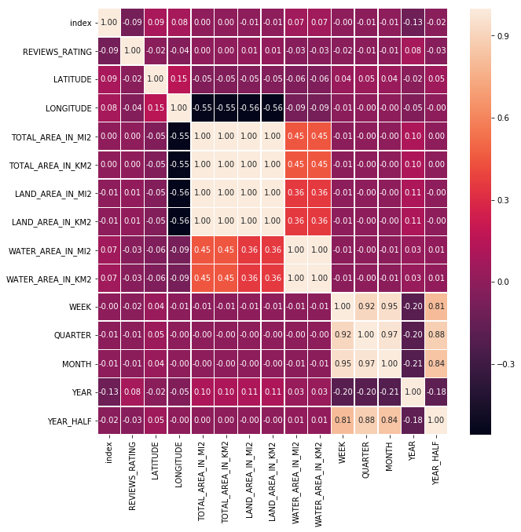

```python
# Are there any interesting correlations?
# There's no significant outlier for the correlations in the row/column 'REVIEWS_RATING'.
# But we also have too little user information.
fig, ax = plt.subplots(figsize=(10,10))
sns.heatmap(df_fact_rating_2.corr(), annot=True, fmt=".2f", linewidths=.5, ax=ax);
```

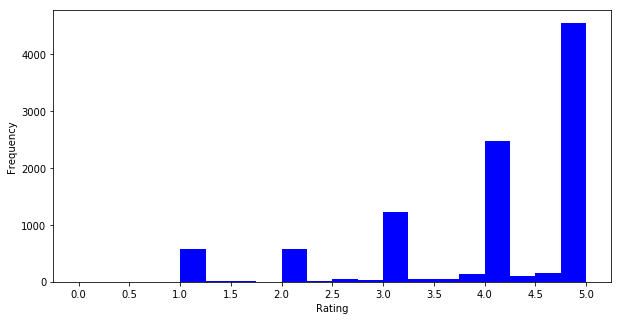

```python
# How are the ratings distributed in general? Let's build a histogram to check.
data = df_fact_rating_2

data['REVIEWS_RATING'].plot(kind='hist', bins=20, color='b', range=(0,5), figsize=(10,5));
plt.xlabel('Rating');
plt.ylabel('Frequency');
plt.xticks(np.arange(0, 5.5, 0.5));
```

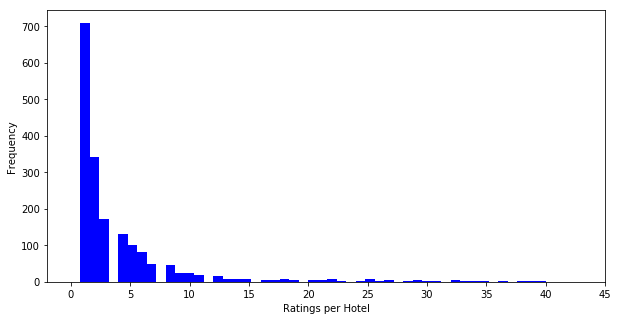

```python
# Which Hotel has the best average rating?
# Lets first check another histogram of the hotel ratings count to get feeling for a meaningful filter for the count
# as we have more than 2000 hotels.

data = pd.merge(df_fact_hotel, df_dim_hotel, how='left',
                left_on=['DW_ID_HASH_KEY_HOTEL'], right_on=['DW_ID_HASH_KEY'])

data['RATING_COUNT'].plot(kind='hist', bins=50, color='b', range=(0,40), figsize=(10,5));
plt.xlabel('Ratings per Hotel');
plt.ylabel('Frequency');
plt.xticks(np.arange(0,50, 5));
```

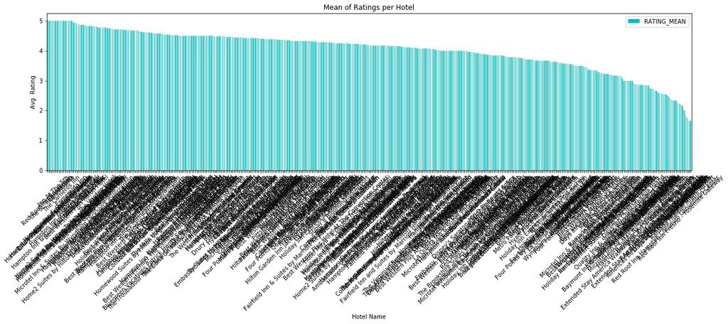

```python
# We should be safe with more than 5 reviews.
min_count = 5

data = pd.merge(df_fact_hotel[df_fact_hotel['RATING_COUNT'] > min_count], df_dim_hotel, how='left',
                left_on=['DW_ID_HASH_KEY_HOTEL'], right_on=['DW_ID_HASH_KEY'])\
                .sort_values('RATING_MEAN', ascending=False)

data.plot(x='NAME_HOTEL',y='RATING_MEAN',kind='bar',
              title='Mean of Ratings per Hotel',figsize=(20,5), color='c', rot=45);
plt.ylabel('Avg. Rating');
plt.xlabel('Hotel Name');
```

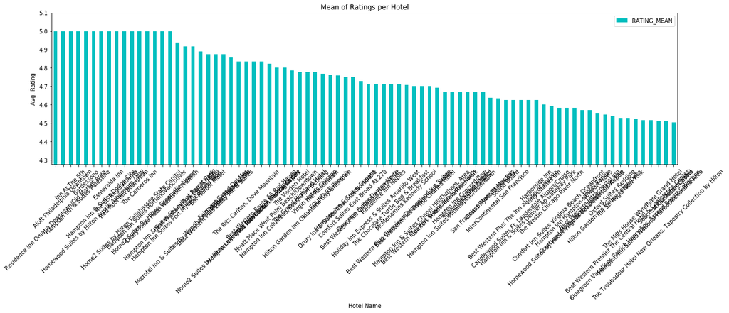

```python
# Well, maybe not... This looks ugly.
# But, we can set a filter for a min avg. rating
min_count = 5
min_avg_rating = 4.5

data = pd.merge(df_fact_hotel[(df_fact_hotel['RATING_COUNT'] > min_count) & (df_fact_hotel['RATING_MEAN'] > min_avg_rating)],
                df_dim_hotel, how='left', left_on=['DW_ID_HASH_KEY_HOTEL'], right_on=['DW_ID_HASH_KEY'])\
                .sort_values('RATING_MEAN', ascending=False)

ax = data.plot(x='NAME_HOTEL',y='RATING_MEAN',kind='bar',
              title='Mean of Ratings per Hotel',figsize=(20,5), color='c', rot=45);
ax.set_ylim(min_avg_rating*0.95, 5.1);
plt.ylabel('Avg. Rating');
plt.xlabel('Hotel Name');
```

```python
# Still not really better.
# But if we want to find a good hotel, we probably know about the possible destinations.
print(df_dim_state['NAME_STATE'].unique())
```

```
['Alabama' 'Alaska' 'Arizona' 'Arkansas' 'California' 'Colorado'
 'Connecticut' 'Delaware' 'Florida' 'Georgia' 'Hawaii' 'Idaho' 'Illinois'
 'Indiana' 'Iowa' 'Kansas' 'Kentucky' 'Louisiana' 'Maine' 'Maryland'
 'Massachusetts' 'Michigan' 'Minnesota' 'Mississippi' 'Missouri' 'Montana'
 'Nebraska' 'Nevada' 'New Hampshire' 'New Jersey' 'New Mexico' 'New York'
 'North Carolina' 'North Dakota' 'Ohio' 'Oklahoma' 'Oregon' 'Pennsylvania'
 'Rhode Island' 'South Carolina' 'South Dakota' 'Tennessee' 'Texas' 'Utah'
 'Vermont' 'Virginia' 'Washington' 'West Virginia' 'Wisconsin' 'Wyoming']
```

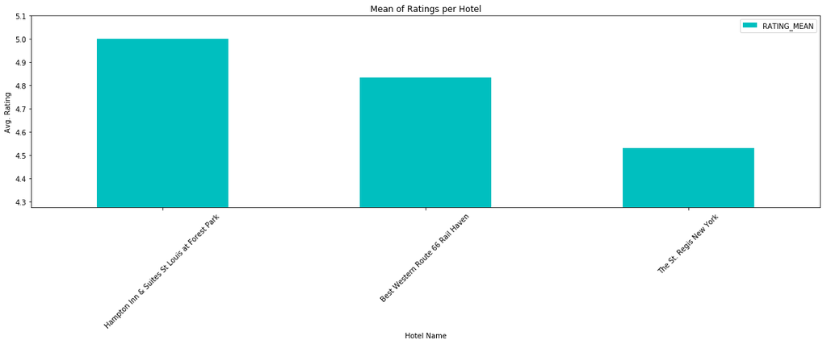

```python
# That's better.
min_count = 5
min_avg_rating = 4.5
states = ['Alabama','Missouri','Vermont', 'New York']

data = pd.merge(df_fact_hotel[(df_fact_hotel['RATING_COUNT'] > min_count) & (df_fact_hotel['RATING_MEAN'] > min_avg_rating)],
                df_dim_hotel, how='left', left_on=['DW_ID_HASH_KEY_HOTEL'], right_on=['DW_ID_HASH_KEY'])\
                .sort_values('RATING_MEAN', ascending=False)

data.drop('DW_ID_HASH_KEY', axis=1, inplace=True)

data = pd.merge(data, df_dim_state, how='left',
                left_on=['DW_ID_HASH_KEY_STATE'], right_on=['DW_ID_HASH_KEY'])

ax = data[data['NAME_STATE'].isin(states)].plot(x='NAME_HOTEL',y='RATING_MEAN',kind='bar',
              title='Mean of Ratings per Hotel',figsize=(20,5), color='c', rot=45);
ax.set_ylim(min_avg_rating*0.95, 5.1);
plt.ylabel('Avg. Rating');
plt.xlabel('Hotel Name');
```

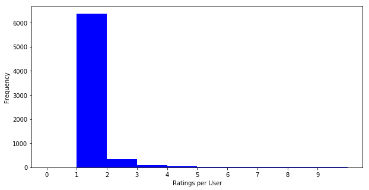

```python
# Are there any 'power-users'?
# We certainly cannot find out with a histogram.
data = pd.merge(df_fact_user, df_dim_user, how='left',
                left_on=['DW_ID_HASH_KEY_USER'], right_on=['DW_ID_HASH_KEY'])

data['RATING_COUNT'].plot(kind='hist', bins=10, color='b', range=(0,10), figsize=(10,5));
plt.xlabel('Ratings per User');
plt.ylabel('Frequency');
plt.xticks(np.arange(0,10, 1));
```

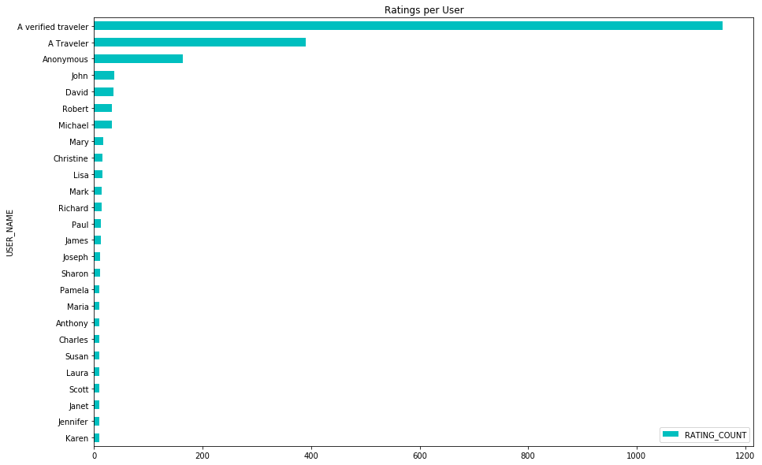

```python
# Some of these people really wrote a lot of reviews, although the first 3 look like a 'John Doe'.
data[data['RATING_COUNT'] > 8].sort_values('RATING_COUNT').plot(x='USER_NAME',y='RATING_COUNT',kind='barh',
              title='Ratings per User',figsize=(15,10), color='c');
```

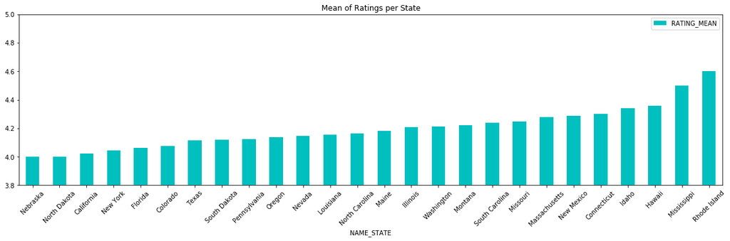

```python
# Which states have best avg rating?
# Feel free to set a min avg. rating.
min_avg_rating = 4

data = pd.merge(df_fact_state[df_fact_state['RATING_MEAN'] >= min_avg_rating], df_dim_state, how='left',
                left_on=['DW_ID_HASH_KEY_STATE'], right_on=['DW_ID_HASH_KEY'])\
                .sort_values('RATING_MEAN', ascending=True)

ax = data.plot(x='NAME_STATE',y='RATING_MEAN',kind='bar',
              title='Mean of Ratings per State',figsize=(20,5), color='c', rot=45);
ax.set_ylim(min_avg_rating*0.95, 5);
```

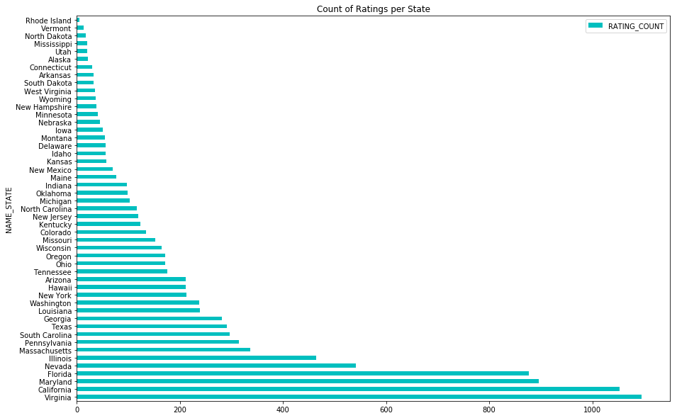

```python
## Which state has the most ratings ratings
data = pd.merge(df_fact_state, df_dim_state, how='left',
                left_on=['DW_ID_HASH_KEY_STATE'], right_on=['DW_ID_HASH_KEY'])\
                .sort_values('RATING_COUNT', ascending=False)

data.plot(x='NAME_STATE',y='RATING_COUNT',kind='barh',
              title='Count of Ratings per State',figsize=(15,10), color='c');
```

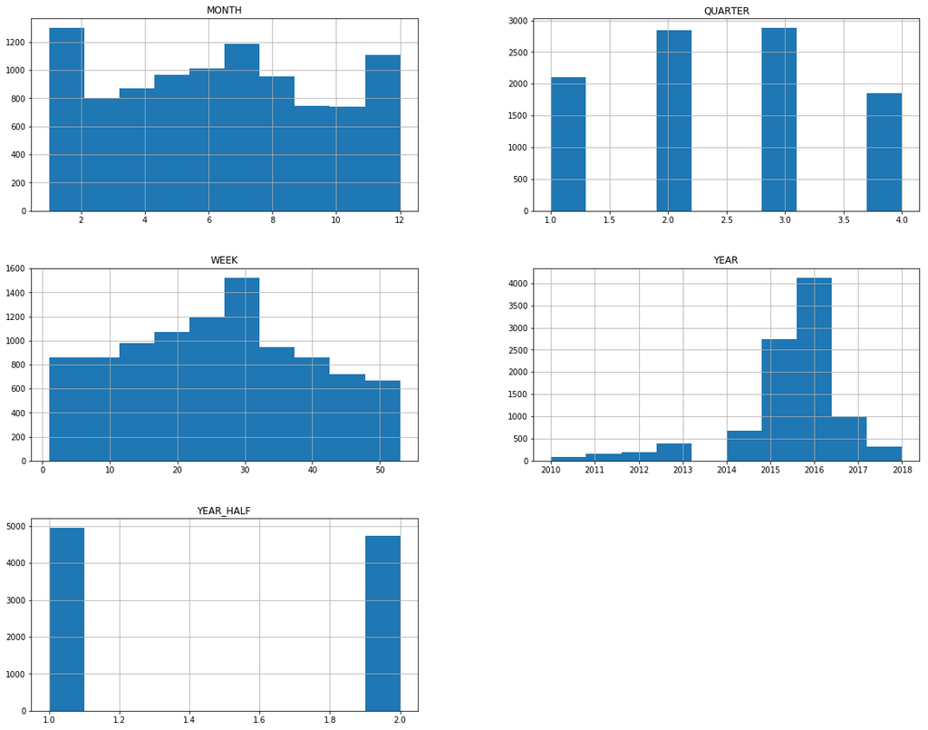

```python
# Also, lets check the time dimensions when the users create their ratings.
# It's interesting to see, that there are peaks at the start and end of the year for the histogram of 'MONTH',
# but the other dimensions show a different picture.
# They clearly indicate that reviews are created in summer weeks/months.
# Furthermore, most of the reviews were created in 2015 and 2016.
df_fact_rating_2[['CLDR_DATE', 'DAY_NAME', 'WEEK', 'QUARTER', 'MONTH', 'YEAR', 'YEAR_HALF']].hist(figsize=(20,16));
```

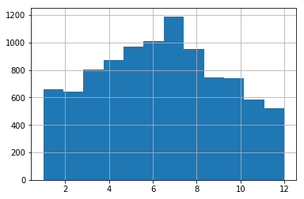

```python
# Amending the bin size shows that this was due to the bins parameter default.
df_fact_rating_2['MONTH'].hist(bins=12);
```

```python
from subprocess import call
call(['python', '-m', 'nbconvert', 'datafiniti_hotel_reviews.ipynb'])
```

```
0
```